# CRA_proteomics_QC

James Read, PhD

2024-04-19

# Setup

### Import libraries

```r
library(SomaDataIO)
library(Biobase)
library(purrr)
library(tidyr)
library(scales)
library(FactoMineR)
library(dendextend)
library(ggpubr)
library(EDASeq)
library(patchwork)
library(pheatmap)
library(RColorBrewer)
```

## Import data

```r
in.dir = "Path/To/Data"
```

```r
# Input file name
file.name = "SS-2217260_v4.1_Serum.hybNorm.medNormInt.plateScale.calibrate.anmlQC.qcCheck.medNormRefSMP.adat"

# Import the adat file
adat <- read_adat(paste(in.dir, file.name, sep="/"))

# Check the data
is.soma_adat(adat)
```

```
## [1] TRUE
```

```r
class(adat)
```

```
## [1] "soma_adat"  "data.frame"
```

Check file attributes

```r
adat
```

```
## ══ SomaScan Data ═══════════════════════════════════════════════════════════════
##      SomaScan version     v4.1 (7k)
##      Signal Space         7k
##      Attributes intact    ✓
##      Rows                 95
##      Columns              7629
##      Clinical Data        33
##      Features             7596
## ── Column Meta ─────────────────────────────────────────────────────────────────
## ℹ SeqId, SeqIdVersion, SomaId, TargetFullName, Target, UniProt, EntrezGeneID,
## ℹ EntrezGeneSymbol, Organism, Units, Type, Dilution, PlateScale_Reference,
## ℹ CalReference, Cal_PLT11461, ColCheck, CalQcRatio_PLT11461_200174,
## ℹ QcReference_200174, Dilution2
## ── Tibble ──────────────────────────────────────────────────────────────────────
## # A tibble: 95 × 7,630
##    row_names      PlateId  PlateRunDate ScannerID PlatePosition SlideId Subarray
##    <chr>          <chr>    <chr>        <chr>     <chr>           <dbl>    <dbl>
##  1 258633851958_1 PLT11461 2022-06-18   SG120641… A1            2.59e11        1
##  2 258633851967_1 PLT11461 2022-06-18   SG120641… A10           2.59e11        1
##  3 258633851990_1 PLT11461 2022-06-18   SG120641… A11           2.59e11        1
##  4 258633851991_1 PLT11461 2022-06-18   SG120641… A12           2.59e11        1
##  5 258633851959_1 PLT11461 2022-06-18   SG120641… A2            2.59e11        1
##  6 258633851960_1 PLT11461 2022-06-18   SG120641… A3            2.59e11        1
##  7 258633851961_1 PLT11461 2022-06-18   SG120641… A4            2.59e11        1
##  8 258633851962_1 PLT11461 2022-06-18   SG120641… A5            2.59e11        1
##  9 258633851963_1 PLT11461 2022-06-18   SG120641… A6            2.59e11        1
## 10 258633851964_1 PLT11461 2022-06-18   SG120641… A7            2.59e11        1
## # ℹ 85 more rows
## # ℹ 7,623 more variables: SampleId <chr>, SampleType <chr>,
## #   PercentDilution <int>, SampleMatrix <chr>, Barcode <chr>, Barcode2d <chr>,
## #   SampleName <chr>, SampleNotes <lgl>, AliquotingNotes <chr>,
## #   SampleDescription <chr>, …
## ════════════════════════════════════════════════════════════════════════════════
```

```r
summary(adat[, tail(names(adat), 3)])
```

```
##  seq.9995.6          seq.9997.12         seq.9999.1
##  Target : DUT        Target : UBXN4:CD 1 Target : IRF6
##  Min    :   235.3    Min    :    69.5    Min    :    84.7
##  1Q     : 11619.5    1Q     : 10183.5    1Q     :  5935.4
##  Median : 26826.4    Median : 16368.8    Median : 11613.4
##  Mean   : 27757.9    Mean   : 15696.0    Mean   : 11138.1
##  3Q     : 40055.5    3Q     : 21169.3    3Q     : 16401.0
##  Max    : 77599.0    Max    : 30499.4    Max    : 29830.0
##  sd     : 19841.8    sd     :  8284.7    sd     :  6959.3
##  MAD    : 20664.9    MAD    :  8198.8    MAD    :  7608.0
##  IQR    : 28436.0    IQR    : 10985.8    IQR    : 10465.6
```

```r
# first 10 analytes; see AptName above
getAnalytes(adat) %>% head(10)
```

```
##  [1] "seq.10000.28" "seq.10001.7"  "seq.10003.15" "seq.10006.25" "seq.10008.43"
##  [6] "seq.10010.10" "seq.10011.65" "seq.10012.5"  "seq.10013.34" "seq.10014.31"
```

```r
# how many analytes
getAnalytes(adat) %>% length()
```

```
## [1] 7596
```

```r
# The getAnalyteInfo() function creates a lookup table that links analyte feature
getAnalyteInfo(adat)
```

```
## # A tibble: 7,596 × 20
##    AptName  SeqId SeqIdVersion SomaId TargetFullName Target UniProt EntrezGeneID
##    <chr>    <chr>        <dbl> <chr>  <chr>          <chr>  <chr>   <chr>
##  1 seq.100… 1000…            3 SL019… Beta-crystall… CRBB2  P43320  "1415"
##  2 seq.100… 1000…            3 SL002… RAF proto-onc… c-Raf  P04049  "5894"
##  3 seq.100… 1000…            3 SL019… Zinc finger p… ZNF41  P51814  "7592"
##  4 seq.100… 1000…            3 SL019… ETS domain-co… ELK1   P19419  "2002"
##  5 seq.100… 1000…            3 SL019… Guanylyl cycl… GUC1A  P43080  "2978"
##  6 seq.100… 1001…            3 SL014… Beclin-1       BECN1  Q14457  "8678"
##  7 seq.100… 1001…            3 SL019… Inositol poly… OCRL   Q01968  "4952"
##  8 seq.100… 1001…            3 SL014… SAM pointed d… SPDEF  O95238  "25803"
##  9 seq.100… 1001…            3 SL025… Fc_MOUSE       Fc_MO… Q99LC4  ""
## 10 seq.100… 1001…            3 SL007… Zinc finger p… SLUG   O43623  "6591"
## # ℹ 7,586 more rows
## # ℹ 12 more variables: EntrezGeneSymbol <chr>, Organism <chr>, Units <chr>,
## #   Type <chr>, Dilution <chr>, PlateScale_Reference <dbl>, CalReference <dbl>,
## #   Cal_PLT11461 <dbl>, ColCheck <chr>, CalQcRatio_PLT11461_200174 <dbl>,
## #   QcReference_200174 <dbl>, Dilution2 <dbl>
```

```r
## Clinical Data

# clinical meta data for each sample
getMeta(adat)
```

```
##  [1] "PlateId"                "PlateRunDate"           "ScannerID"
##  [4] "PlatePosition"          "SlideId"                "Subarray"
##  [7] "SampleId"               "SampleType"             "PercentDilution"
## [10] "SampleMatrix"           "Barcode"                "Barcode2d"
## [13] "SampleName"             "SampleNotes"            "AliquotingNotes"
## [16] "SampleDescription"      "AssayNotes"             "TimePoint"
## [19] "ExtIdentifier"          "SsfExtId"               "SampleGroup"
## [22] "SiteId"                 "SubjectID"              "CLI"
## [25] "RMA"                    "HybControlNormScale"    "RowCheck"
## [28] "NormScale_20"           "NormScale_0_005"        "NormScale_0_5"
## [31] "ANMLFractionUsed_20"    "ANMLFractionUsed_0_005" "ANMLFractionUsed_0_5"
```

```r
# also an `n` argument
getMeta(adat, n = TRUE)
```

```
## [1] 33
```

```r
table(adat$SampleType)
```

```
##
##     Buffer Calibrator         QC     Sample
##          9          5          3         78
```

## Extract data

```r
## Analyte data
names(attributes(adat))
```

```
## [1] "names"       "class"       "row.names"   "Header.Meta" "Col.Meta"
## [6] "file_specs"  "row_meta"
```

```r
analyte_pheno = data.frame(attributes(adat)$Col.Meta)
dim(analyte_pheno)
```

```
## [1] 7596   19
```

```r
head(analyte_pheno)
```

```
##      SeqId SeqIdVersion   SomaId
## 1 10000-28            3 SL019233
## 2  10001-7            3 SL002564
## 3 10003-15            3 SL019245
## 4 10006-25            3 SL019228
## 5 10008-43            3 SL019234
## 6 10010-10            3 SL014943
##                                       TargetFullName Target UniProt
## 1                                 Beta-crystallin B2  CRBB2  P43320
## 2 RAF proto-oncogene serine/threonine-protein kinase  c-Raf  P04049
## 3                             Zinc finger protein 41  ZNF41  P51814
## 4                ETS domain-containing protein Elk-1   ELK1  P19419
## 5              Guanylyl cyclase-activating protein 1  GUC1A  P43080
## 6                                           Beclin-1  BECN1  Q14457
##   EntrezGeneID EntrezGeneSymbol Organism Units    Type Dilution
```

[output cut: 20 more lines]

```r
analyte_pheno$SeqId2 = paste0("seq.", gsub("-", ".", analyte_pheno$SeqId))
rownames(analyte_pheno) = analyte_pheno$SeqId2


# Subset data
dat0 = as.data.frame(adat)
dim(dat0)
```

```
## [1]   95 7629
```

```r
colnames(dat0[, 1:40])
```

```
##  [1] "PlateId"                "PlateRunDate"           "ScannerID"
##  [4] "PlatePosition"          "SlideId"                "Subarray"
##  [7] "SampleId"               "SampleType"             "PercentDilution"
## [10] "SampleMatrix"           "Barcode"                "Barcode2d"
## [13] "SampleName"             "SampleNotes"            "AliquotingNotes"
## [16] "SampleDescription"      "AssayNotes"             "TimePoint"
## [19] "ExtIdentifier"          "SsfExtId"               "SampleGroup"
## [22] "SiteId"                 "SubjectID"              "CLI"
## [25] "RMA"                    "HybControlNormScale"    "RowCheck"
## [28] "NormScale_20"           "NormScale_0_005"        "NormScale_0_5"
## [31] "ANMLFractionUsed_20"    "ANMLFractionUsed_0_005" "ANMLFractionUsed_0_5"
## [34] "seq.10000.28"           "seq.10001.7"            "seq.10003.15"
## [37] "seq.10006.25"           "seq.10008.43"           "seq.10010.10"
## [40] "seq.10011.65"
```

```r
# Get sample-level phenotype data
pheno = dat0[, 1:33]
dim(pheno)
```

```
## [1] 95 33
```

```r
pheno[1:5, 1:5]; colnames(pheno)
```

```
##                 PlateId PlateRunDate  ScannerID PlatePosition      SlideId
## 258633851958_1 PLT11461   2022-06-18 SG12064173            A1 258633851958
## 258633851967_1 PLT11461   2022-06-18 SG12064173           A10 258633851967
## 258633851990_1 PLT11461   2022-06-18 SG12064173           A11 258633851990
## 258633851991_1 PLT11461   2022-06-18 SG12064173           A12 258633851991
## 258633851959_1 PLT11461   2022-06-18 SG12064173            A2 258633851959
```

```
##  [1] "PlateId"                "PlateRunDate"           "ScannerID"
##  [4] "PlatePosition"          "SlideId"                "Subarray"
##  [7] "SampleId"               "SampleType"             "PercentDilution"
## [10] "SampleMatrix"           "Barcode"                "Barcode2d"
## [13] "SampleName"             "SampleNotes"            "AliquotingNotes"
## [16] "SampleDescription"      "AssayNotes"             "TimePoint"
## [19] "ExtIdentifier"          "SsfExtId"               "SampleGroup"
## [22] "SiteId"                 "SubjectID"              "CLI"
## [25] "RMA"                    "HybControlNormScale"    "RowCheck"
## [28] "NormScale_20"           "NormScale_0_005"        "NormScale_0_5"
## [31] "ANMLFractionUsed_20"    "ANMLFractionUsed_0_005" "ANMLFractionUsed_0_5"
```

```r
# Get raw data matrix
dat = t(dat0[, 34:ncol(dat0)])
dim(dat)
```

```
## [1] 7596   95
```

```r
dat[1:5, 1:5]
```

```
##              258633851958_1 258633851967_1 258633851990_1 258633851991_1
## seq.10000.28         1328.2         1239.5         1253.3         1118.7
## seq.10001.7          1093.4          711.5          792.1          956.4
## seq.10003.15          287.9          286.0          244.0          269.3
## seq.10006.25         2861.7         2402.1         2183.4         4099.6
## seq.10008.43         1012.1          997.8          960.0         1344.1
##              258633851959_1
## seq.10000.28          105.3
## seq.10001.7           101.1
## seq.10003.15           65.6
## seq.10006.25          111.4
## seq.10008.43           89.6
```

```r
# Check analyte identifiers match raw data
identical(rownames(analyte_pheno), rownames(dat))
```

```
## [1] TRUE
```

```r
# Check sample names match
identical(rownames(pheno), colnames(dat))
```

```
## [1] TRUE
```

Add colors

```r
# Add colors

table(pheno$SampleType)
```

```
##
##     Buffer Calibrator         QC     Sample
##          9          5          3         78
```

```r
ST_col = c("Buffer" = "grey80", "Calibrator" = "orange2",
          "QC" = "royalblue2", "Sample" = "red1")
pheno$ST_col = ST_col[pheno$SampleType]

table(pheno$PlateId)
```

```
##
## PLT11461
##       95
```

```r
P_col = c("PLT11461" = "dodgerblue2")
pheno$P_col = P_col[pheno$PlateId]

table(pheno$RowCheck)
```

```
##
## PASS
##   95
```

```r
RC_col = c("PASS" = "magenta2", "FLAG" = "cyan3")
pheno$RC_col = RC_col[pheno$RowCheck]

table(pheno$PlatePosition)
```

```
##
##  A1 A10 A11 A12  A2  A3  A4  A5  A6  A7  A8  A9  B1 B10 B11 B12  B2  B3  B4  B5
##   1   1   1   1   1   1   1   1   1   1   1   1   1   1   1   1   1   1   1   1
##  B6  B7  B8  B9  C1 C10 C11 C12  C2  C3  C4  C5  C6  C7  C8  C9  D1 D10 D11 D12
##   1   1   1   1   1   1   1   1   1   1   1   1   1   1   1   1   1   1   1   1
##  D2  D3  D4  D5  D6  D7  D8  D9  E1 E10 E11 E12  E2  E3  E4  E5  E6  E7  E8  E9
##   1   1   1   1   1   1   1   1   1   1   1   1   1   1   1   1   1   1   1   1
##  F1 F10 F11 F12  F2  F3  F4  F5  F6  F7  F8  F9  G1 G10 G11 G12  G2  G3  G4  G5
##   1   1   1   1   1   1   1   1   1   1   1   1   1   1   1   1   1   1   1   1
##  G6  G7  G8  G9  H1 H10 H11  H2  H3  H4  H5  H6  H7  H8  H9
##   1   1   1   1   1   1   1   1   1   1   1   1   1   1   1
```

```r
table(pheno$Subarray)
```

```
##
##  1  2  3  4  5  6  7  8
## 12 12 12 12 12 12 12 11
```

# Phase 1 QC

This phase of the QC with assess the control samples and general aptamer characteristics.

### 1) Boxplots

Boxplot to visualize sample normalisation. The x-axis is sample index in the order they were run. The y-axis is the Relative Fluoroescence Units (RFU), which is the measure of target protein expression

#### Normalized

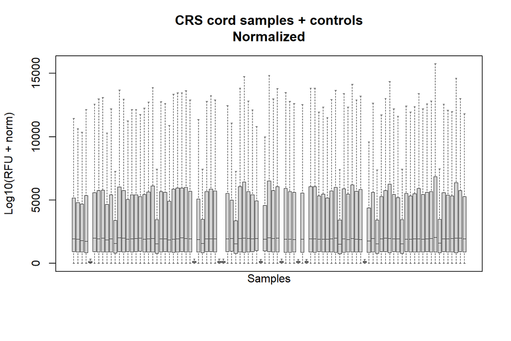

```r
# Outline set to 'FALSE' to omit points on the graph
boxplot(dat, main = "CRS cord samples + controls\nNormalized",
        xlab = "Samples\n\n\n", ylab = "Log10(RFU + norm)",
        cex=0.6, bg.col = alpha("grey", 0.7),
        xaxt = 'n', lwd = 0.3, outline = FALSE)
```

#### Normalized + Log10 transformation

**Sample type**

The Buffer samples exhibit notably lower expression, as expected. The QC samples also show slightly decreased overall expression

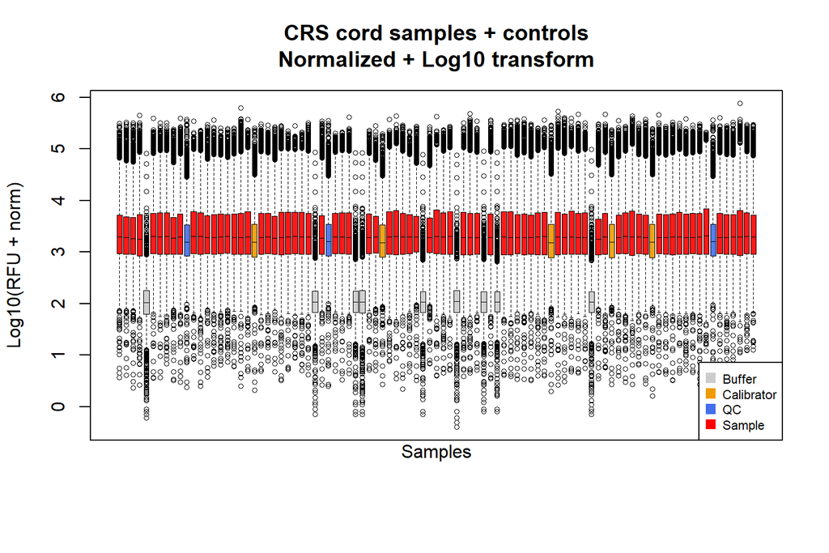

```r
# Log10 - sample type
boxplot(log10(dat), main = "CRS cord samples + controls\nNormalized + Log10 transform",
        xlab = "Samples\n\n\n", ylab = "Log10(RFU + norm)", cex=0.6,
        bg.col = alpha("grey", 0.7),xaxt = 'n', lwd = 0.3,
        col = alpha(pheno$ST_col, 0.9))
legend("bottomright", pch=15, pt.cex = 1.2, cex = 0.7,
       legend = c("Buffer", "Calibrator", "QC", "Sample"),
       col = c("grey80", "orange2", "royalblue2", "red1"))
```

**Plate**

(All sample were run on a single plate for this experiment)

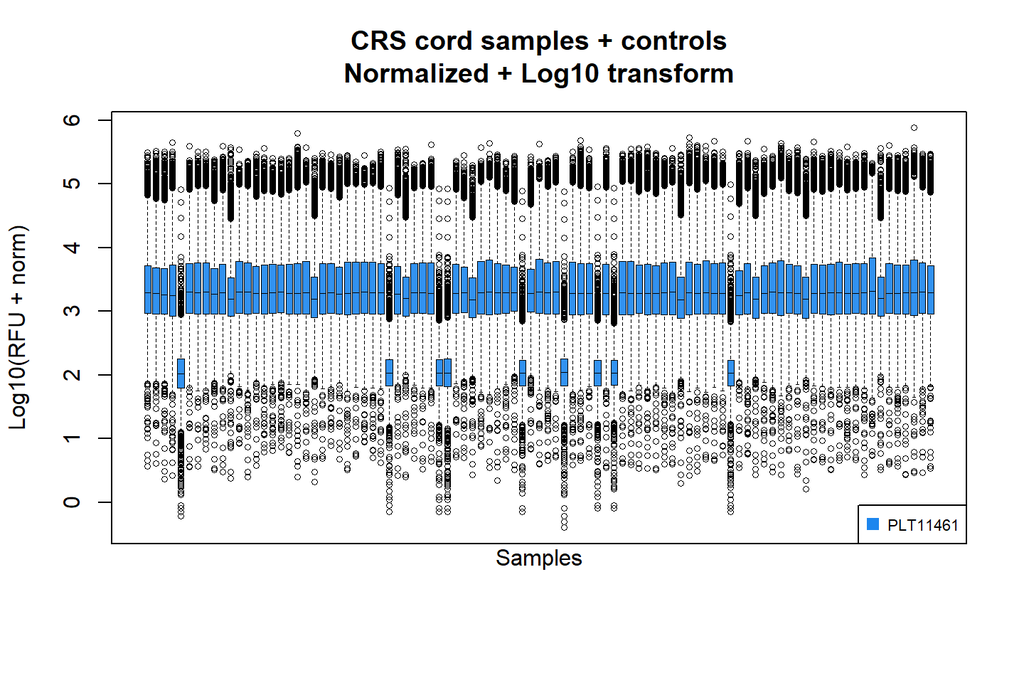

```r
boxplot(log10(dat), main = "CRS cord samples + controls\nNormalized + Log10 transform",
        xlab = "Samples\n\n\n", ylab = "Log10(RFU + norm)", cex=0.6,
        bg.col = alpha("grey", 0.7), xaxt = 'n', lwd = 0.3,
        col = alpha(pheno$P_col, 0.9))
legend("bottomright", pch=15, pt.cex = 1.2, cex = 0.7,
       legend = c("PLT11461"), col = c("dodgerblue2"))
```

**Flag**

(All sample passed the row check criteria in this experiment)

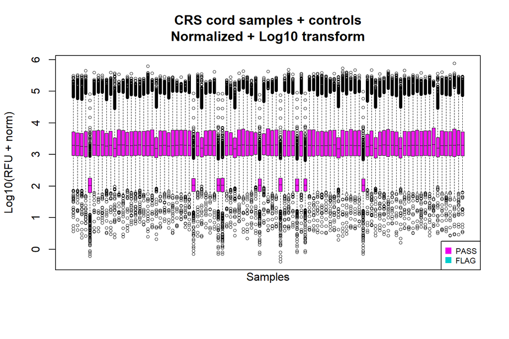

```r
boxplot(log10(dat), main = "CRS cord samples + controls\nNormalized + Log10 transform",
        xlab = "Samples\n\n\n", ylab = "Log10(RFU + norm)", cex=0.6,
        bg.col = alpha("grey", 0.7), xaxt = 'n', lwd = 0.3,
        col = alpha(pheno$RC_col, 0.9))
legend("bottomright", pch=15, pt.cex = 1.2, cex = 0.7,
       legend = c("PASS", "FLAG"), col = c("magenta2", "cyan3"))
```

### 2) remove inappropriate aptamers

There are several additional aptamers which are related to SomaLogic’s QC, such as Hybridization Controls and ‘Spuriomer’, which are randomly constructed sequences. These may be of use to check up if there are any anomalies in the signal intensity, but will remove for now.

```r
table(analyte_pheno$Type)
```

```
##
## Hybridization Control Elution                    Non-Biotin
##                            12                            10
##                 Non-Cleavable                     Non-Human
##                             4                            27
##                       Protein                      Spurimer
##                          7523                             1
##                     Spuriomer
##                            19
```

Additionally, SomaLogic includes their entire catalog which has non-human proteins. Of these, only mouse has substantial numbers.

```r
table(analyte_pheno$Organism)
```

```
##
##         African clawed frog Bacillus stearothermophilus
##                           3                           1
##      Common eastern firefly            Ensifer meliloti
##                           2                           1
##              European elder                Gila monster
##                           2                           3
##                       HIV-1                       HIV-2
##                           1                           1
##                      Hornet                       Human
##                           3                        7335
##                   Jellyfish                       Mouse
##                           3                         236
##           Red alga|Red alga                  strain K12
##                           1                           1
##        Thermus thermophilus
##                           3
```

For this study, will retain only aptamers associates with Human proteins

Check that the data set match

```r
identical(rownames(analyte_pheno), rownames(dat))
```

```
## [1] TRUE
```

Create index of samples to retain

```r
idx = analyte_pheno$Type == "Protein" & analyte_pheno$Organism == "Human"
table(idx)
```

```
## idx
## FALSE  TRUE
##   308  7288
```

There are 308 aptamers of no interest to this study.

#### Filter data set

There are now 7,288 aptamers available for analysis

```r
dat = dat[idx, ]
analyte_pheno = analyte_pheno[idx, ]
dim(dat)
```

```
## [1] 7288   95
```

Check data sets

```r
table(analyte_pheno$Type, analyte_pheno$Organism)
```

```
##
##           Human
##   Protein  7288
```

```r
identical(rownames(analyte_pheno), rownames(dat))
```

```
## [1] TRUE
```

### Compare samples to buffer

Create separate data sets by sample type

```r
q1 = dat[, pheno$SampleType == "Buffer"]
q2 = dat[, pheno$SampleType == "Calibrator"]
q3 = dat[, pheno$SampleType == "QC"]
q4 = dat[, pheno$SampleType == "Sample"]
```

Calculate mean expression across samples for each aptamer. These values are ordered by increasing mean expression with respect to the Buffer samples.

```r
q1b = rowMeans(q1); q1b = q1b[order(q1b)]
q2b = rowMeans(q2); q2b = q2b[names(q1b)]
q3b = rowMeans(q3); q3b = q3b[names(q1b)]
q4b = rowMeans(q4); q4b = q4b[names(q1b)]
```

Plot the ranked expression for each aptamer by sample type.

The buffer sample

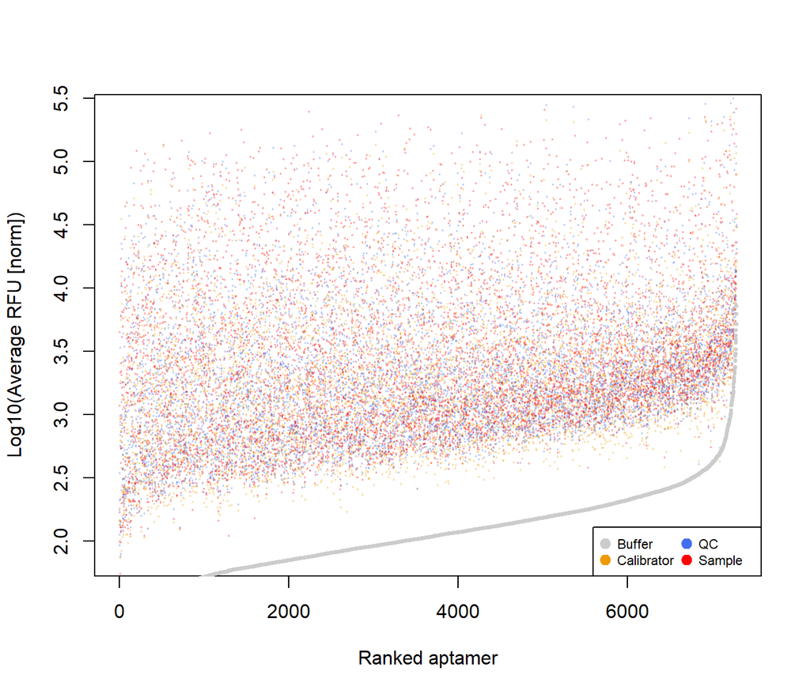

```r
plot(log10(q2b), cex = 0.2, pch = 19, col = alpha("orange2", 0.2),
     xlab = "Ranked aptamer", ylab = "Log10(Average RFU [norm])",
     main = "")
points(log10(q3b), cex = 0.2, pch = 19, col = alpha("royalblue2", 0.2))
points(log10(q4b), cex = 0.2, pch = 19, col = alpha("red1", 0.2))
points(log10(q1b), cex = 0.4, pch = 19, col = alpha("grey80", 0.9))
legend("bottomright", pch=19, pt.cex = 1.2, cex = 0.7, ncol=2,
       legend = c("Buffer", "Calibrator", "QC", "Sample"),
       col = c("grey80", "orange2", "royalblue2", "red1"))
```

Create a data frame of the sample-to-buffer differences and ratios

```r
df1 = data.frame("Buffer" = q1b, "Sample" = q4b)
df1$Diff = df1$Sample - df1$Buffer
df1$Ratio = df1$Sample/df1$Buffer
head(df1)
```

```
##                Buffer     Sample       Diff       Ratio
## seq.10554.23 1.555556   99.70000   98.14444   64.092857
## seq.10485.56 2.811111  168.78718  165.97607   60.042870
## seq.6416.8   3.155556   52.33974   49.18419   16.586538
## seq.20073.22 4.044444 4501.43590 4497.39145 1112.992392
## seq.10741.22 5.166667 1181.36667 1176.20000  228.651613
## seq.10670.26 5.966667   55.62692   49.66026    9.322948
```

Plot the Log10 Buffer/Sample average expression difference versus ratio

This plot shows that the vast majority of samples follow a log-linear relationship between the difference and ratio relative to Buffer samples. The red and blue line represent the filter threshold to be used.

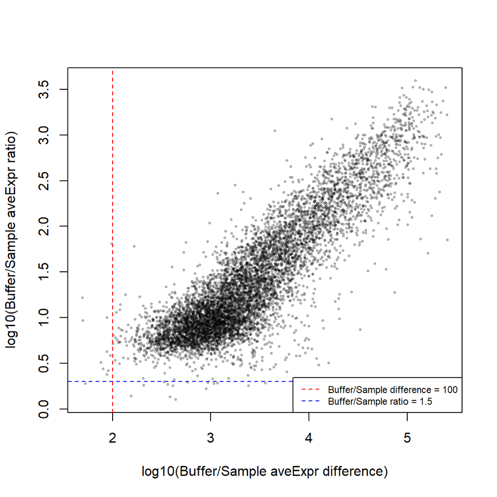

```r
plot(log10(df1$Diff), log10(df1$Ratio), cex = 0.4, pch = 19,
     col = alpha("black", 0.2),
     xlab = "log10(Buffer/Sample aveExpr difference)",
     ylab = "log10(Buffer/Sample aveExpr ratio)")
abline(v=log10(100), lty=2, col = "red")
abline(h=log10(2), lty=2, col = "blue")
legend("bottomright", cex = 0.7, lty=2, col = c("red", "blue"),
       legend = c("Buffer/Sample difference = 100", "Buffer/Sample ratio = 1.5"))
```

This is a lenient threshold which could be raised if needed.

```r
table(df1$Diff < 100)
```

```
##
## FALSE  TRUE
##  7277    11
```

```r
table(df1$Ratio < 2)
```

```
##
## FALSE  TRUE
##  7273    15
```

```r
table(df1$Diff < 100 | df1$Ratio < 2)
```

```
##
## FALSE  TRUE
##  7263    25
```

```r
# Create index of aptamers to retain
idx = df1$Diff < 100 | df1$Ratio < 2
idx2 = rownames(df1)[!idx]
```

This threshold will remove 25/7288 (0.34%) aptamers

```r
(table(idx)[[2]]/nrow(df1))*100
```

```
## [1] 0.3430296
```

Filter out aptamers with expression similar to the Buffer (reagents + Media) samples

```r
dat1 = dat[idx2, ]; dim(dat1)
```

```
## [1] 7263   95
```

```r
analyte_pheno1 = analyte_pheno[idx2, ]
```

Check data sets match

```r
identical(rownames(dat1), rownames(analyte_pheno1))
```

```
## [1] TRUE
```

### Preliminary PCA

Initial PCA analysis using all aptamers and including control samples

Run PCA

```r
set.seed(42); yZ = PCA(t(dat1), ncp = 10, scale.unit = TRUE, graph = FALSE)
y1 = yZ$ind$coord
# Display PCA output
head(yZ$eig)
```

```
##        eigenvalue percentage of variance cumulative percentage of variance
## comp 1  3362.6380              46.298196                          46.29820
## comp 2   971.8337              13.380610                          59.67881
## comp 3   444.6143               6.121634                          65.80044
## comp 4   211.0492               2.905814                          68.70625
## comp 5   189.0126               2.602404                          71.30866
## comp 6   142.5892               1.963227                          73.27188
```

Create dataframe with PCs and pheno

```r
w1 = data.frame(y1, pheno)
```

Create axis labels to show percentages

```r
lab1 = paste0("PC 1 (", round(yZ$eig[1, 2],2), "%)")
lab2 = paste0("PC 2 (", round(yZ$eig[2, 2],2), "%)")
```

Plot by Sample type

This plot shows separation of the Buffer samples on the first PC, and the QC and claibrator samples on the 2nd PC. The Buffer, QC, and Calibration control samples all display tight clustering. The experimental samples display some variability across the 2nd PC, and one sample in particular stands out.

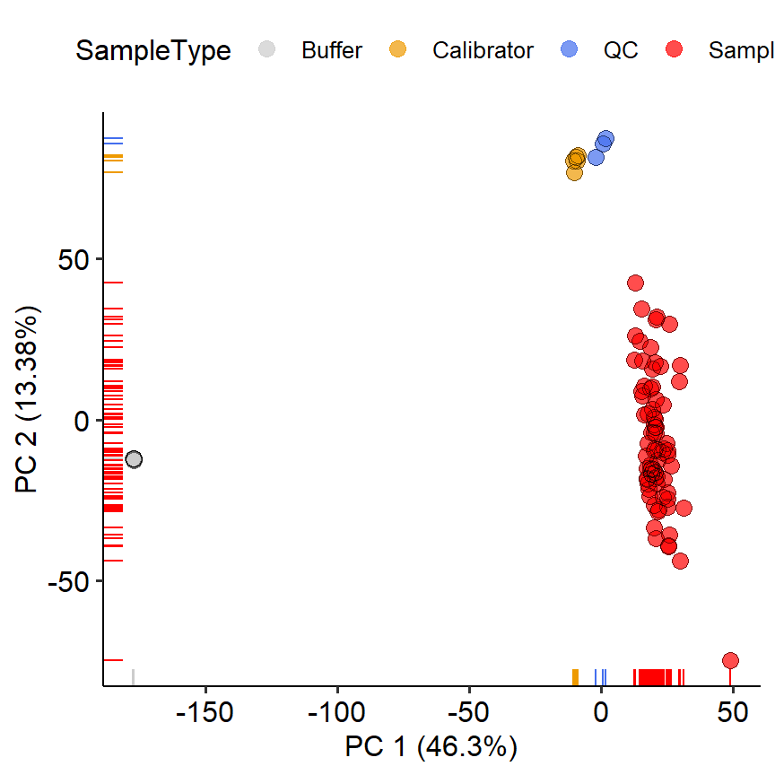

```r
ggplot(w1, aes(x = Dim.1, y = Dim.2, color = SampleType)) +
  geom_point(aes(color = SampleType), size = 3, alpha = 0.7) +
  geom_point(shape = 1, color = "black", size = 3, alpha = 0.5) +
  geom_rug() + theme_pubr() + labs(x= lab1, y = lab2) +
  guides(fill = guide_legend(override.aes = list(linetype = 0)),
         color = guide_legend(override.aes = list(linetype = 0)))+
  scale_color_manual(values=ST_col)
```

### Calibration and QC samples by sequence order

Calibration samples over sequence order.

Subset to Calibration samples

```r
csamp = dat1[, pheno$SampleType == "Calibrator"]
cphen = pheno[pheno$SampleType == "Calibrator", ]
```

Plot the samples used to calibrate the RFU signal intensity across the plates. This plots shows aligned sample medians for the calibration samples.

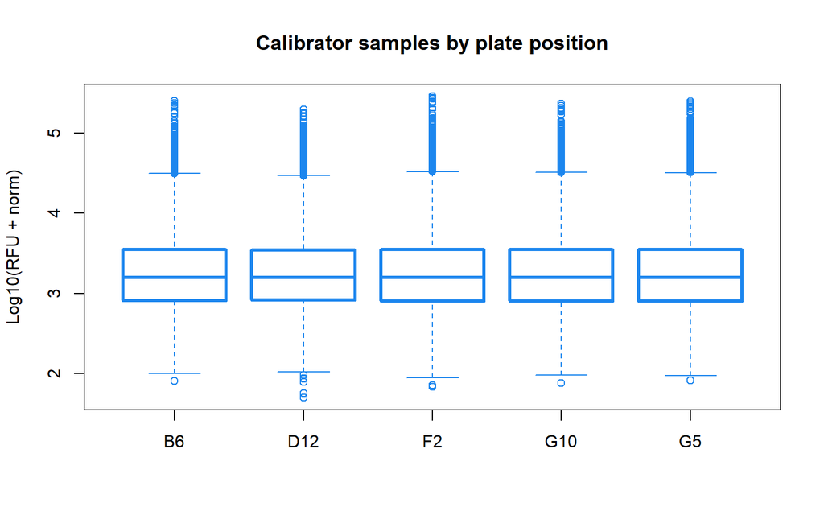

```r
boxplot(log10(csamp), col="white", border = cphen$P_col,
        boxlwd = 3, names=cphen$PlatePosition, ylab = "Log10(RFU + norm)",
        main = "Calibrator samples by plate position")
```

QC samples over sequence order

Subset to QC samples

```r
csamp = dat1[, pheno$SampleType == "QC"]
cphen = pheno[pheno$SampleType == "QC", ]
```

Plot the samples used for inter- and intra-plate QC. This plots shows aligned sample medians for the QC samples.

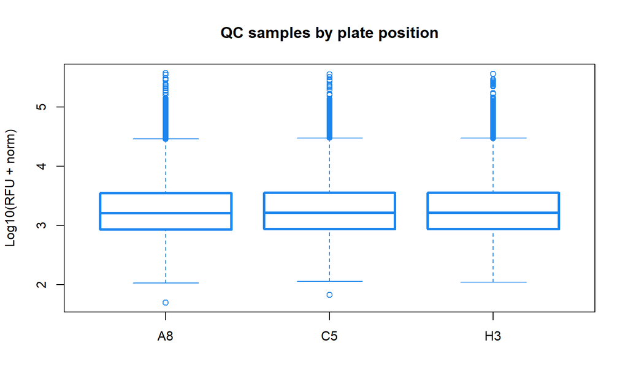

```r
boxplot(log10(csamp), col="white", border = cphen$P_col,
        boxlwd = 3, names=cphen$PlatePosition, ylab = "Log10(RFU + norm)",
        main = "QC samples by plate position")
```

In general, this indicates that the signal intensity and samples alignment was successful, and the data is good quality in this respect.

### Remove buffer, Calibrator, and QC samples

Retain only the Experimental samples

```r
table(pheno$SampleType)
```

```
##
##     Buffer Calibrator         QC     Sample
##          9          5          3         78
```

```r
dat1 = dat1[, pheno$SampleType == "Sample"]
pheno1 = pheno[pheno$SampleType == "Sample", ]
table(pheno1$SampleType)
```

```
##
## Sample
##     78
```

Check that all data sets match

```r
identical(colnames(dat1), rownames(pheno1))
```

```
## [1] TRUE
```

```r
identical(rownames(dat1), rownames(analyte_pheno1))
```

```
## [1] TRUE
```

```r
dim(dat1)
```

```
## [1] 7263   78
```

# Phase 2 QC

This phase of the QC will assess the quality of the experimental samples and the assess the filtered aptamers.

### Add in other clinical metadata

The data set from returned from SomaLogic (.adata file) didn’t contain the relevant clinical/experimental variables of interest of the subjects (e.g., Small for Gestational Age (SGA) status).

Bring in the additional information

```r
in.dir = "C:/Users/jread/Desktop/Work/UofA/CRS/SomaScan_data/James_analysis/Data"
```

First, the clinical data uses the ArcID system, so bring in a joining file with arcIDs and somaLogic Ids so the data set can be match up

```r
setwd(in.dir)
join.file = read.csv("CRS_Cord_sample_ArcID_join.csv", row.names = 1)
dim(join.file)
```

```
## [1] 78  6
```

confirm all samples are present and in the correct order

```r
# Check presence
table(rownames(pheno1) %in% rownames(join.file))
```

```
##
## TRUE
##   78
```

```r
# Check identical order
identical(rownames(pheno1), rownames(join.file))
```

```
## [1] TRUE
```

Transfer ArcID to proteomics data set

```r
pheno1$ArcID = as.character(join.file$arcid)

# Check data sets match

identical(rownames(pheno1), colnames(dat1))
```

```
## [1] TRUE
```

```r
# Make ArcID the rownames identifier
```

```r
setwd(in.dir)
clin.dat = read.csv("Cord_ID7_Phenodata_n145_072622.csv", row.names = 1)
dim(clin.dat)
```

```
## [1] 145  55
```

The ArcID are clin.dat’s row names

```r
head(rownames(clin.dat))
```

```
## [1] "13816" "17534" "17846" "13043" "14456" "16731"
```

Filter clinical data to only those sample present in the proteomics data

```r
# Check all samples are present
table(rownames(clin.dat) %in% pheno1$ArcID)
```

```
##
## FALSE  TRUE
##    67    78
```

```r
# Filter
clin.dat2 = clin.dat[pheno1$ArcID, ]

# Check data sets match
identical(pheno1$ArcID, rownames(clin.dat2))
```

```
## [1] TRUE
```

Transfer clinical data to pheno file

```r
pheno2 = cbind(pheno1, clin.dat2[, c(3:ncol(clin.dat2))])
```

Housekeeping

```r
table(pheno2$sex)
```

```
##
##   1. male 2. female
##        38        40
```

```r
pheno2$sex = ifelse(pheno2$sex == "1. male", "Male", "Female")

table(pheno2$sga)
```

```
##
## 0. AGA 1. SGA
##     40     38
```

```r
pheno2$sga = ifelse(pheno2$sga == "0. AGA", "AGA", "SGA")


table(pheno2$sex, pheno2$sga)
```

```
##
##          AGA SGA
##   Female  19  21
##   Male    21  17
```

Add colors for new variables of interest

```r
# sex, kidethb_new, sga, bestgest, momdelivery, mombmi, momage

Sex_col = c("Female" = "firebrick1", "Male" = "cornflowerblue")
pheno2$Sex_col = Sex_col[pheno2$sex]

SGA_col = c("AGA" = "limegreen", "SGA" = "magenta3")
pheno2$SGA_col = SGA_col[pheno2$sga]
```

## Aptamer level QC

It is common for SomaLogic data set to flag a number of aptamers for RFU intensites outside a standardised range. This is common as different dataset will have different expression intensities depending on the experimental context and sample source. In general these aptamers are flagged because of (potentially important) biological variation rather than undesirable technical variation. The aptamers should be included for downstream analysis, but it’s worth noting so that can be checked in case they are technical outliers.

In this study 272/7263 (3.74%) aptamers were flagged.

```r
table(analyte_pheno1$ColCheck)
```

```
##
## FLAG PASS
##  272 6991
```

### Check duplicate aptamers

SomaScan has many aptamers which correspond to the same Target protein.

```r
table(duplicated(analyte_pheno1$Target))
```

```
##
## FALSE  TRUE
##  6575   688
```

Create an index of aptamers which correspond to duplicate target proteins. There are 1,315.

```r
idx = analyte_pheno1$Target[duplicated(analyte_pheno1$Target)]
table(analyte_pheno1$Target %in% idx)
```

```
##
## FALSE  TRUE
##  5948  1315
```

To assess the similarity of these aptamers, subset to aptamers which correspond to duplicate target proteins.

```r
d.dat = dat1[which(analyte_pheno1$Target %in% idx), ]
d.ap = analyte_pheno1[which(analyte_pheno1$Target %in% idx), ]
# check they match
identical(rownames(d.dat), rownames(d.ap))
```

```
## [1] TRUE
```

Run PCA analysis on this subset

```r
set.seed(42); yZ = PCA(log10(d.dat), ncp = 10, scale.unit = TRUE, graph = FALSE)
y1 = yZ$ind$coord
```

Create data frame containing PCA output and phenodata

```r
w1 = data.frame(y1, d.ap)
```

Plot the first two PC with a line linking aptamers which encode the same target protein.

The plot shows that the linked aptamers *do not* occupy the same principal component space, indicating they may represent different types of the same target protein.

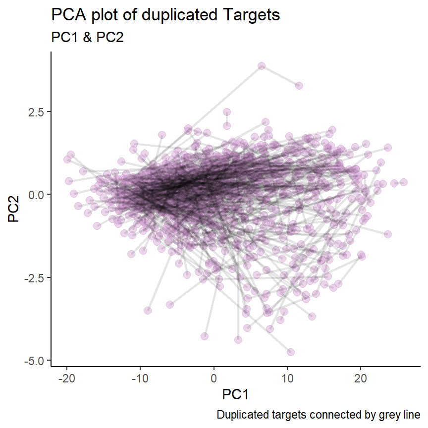

```r
ggplot(w1, aes(x=Dim.1,y=Dim.2)) + theme_classic() +
  geom_point(aes(color= Organism), size=2.5) +
  scale_color_manual(values=alpha(c("plum3"), 0.4)) +
  geom_line(aes(group = Target), lwd=0.8, alpha = 0.1) +
  theme(legend.position = "none") + xlab("PC1") + ylab("PC2") +
  labs(title = "PCA plot of duplicated Targets", subtitle = "PC1 & PC2",
       caption = "Duplicated targets connected by grey line")
```

Although these aptamers correspond to the same target/protein, they may represent different conformations/subunits/structures/activated forms/etc… They will be retained for now and all analysis will be at the aptamer level. The exact characteristics of each aptamer can be checked with the SomaScan.db package

### Aptamer distributions

Plot density distribution of the RFU expression across samples for each aptamer.

The plot shows a range of intensity distributions, as expected.

```r
dens <- apply(dat1, 1, density)

plot(NA, xlim= c(-10, 5000), ylim=range(sapply(dens, "[", "y")),
     main = "Density plot\nAptamer distribution (n = 7,263)", ylab="")
invisible(mapply(lines, dens, col = 1:nrow(dat1), lwd = 0.5))
```

[output not shown]

## Sample level QC

### Sample distributions

Plot density distribution of the RFU expression across aptamers for each sample.

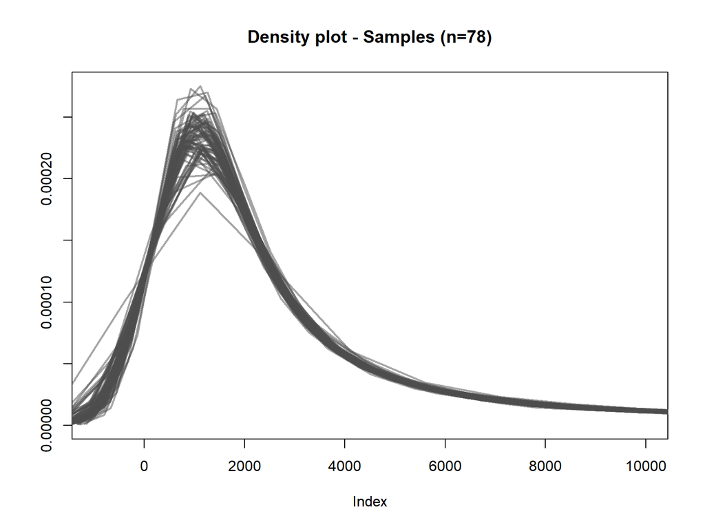

```r
dens <- apply(dat1, 2, density)
plot(NA, xlim= c(-1000, 10000), ylim=range(sapply(dens, "[", "y")),
          main = "Density plot - Samples (n=78)", ylab="")
invisible(mapply(lines, dens, col=alpha("grey30", 0.5), lwd = 2))
```

No noticeable difference when colored by SGA

[figure not shown]

```r
plot(NA, xlim= c(-1000, 10000), ylim=range(sapply(dens, "[", "y")),
     main = "Density plot - Samples (n=78)\nSGA status", ylab="")
invisible(mapply(lines, dens, col=alpha(pheno2$SGA_col, 0.5), lwd = 2))
legend("topright", lty = 1, lwd = 3, pt.cex = 1.2, cex = 0.7,
       legend = c("AGA", "SGA"), col = c("limegreen", "magenta3"))
```

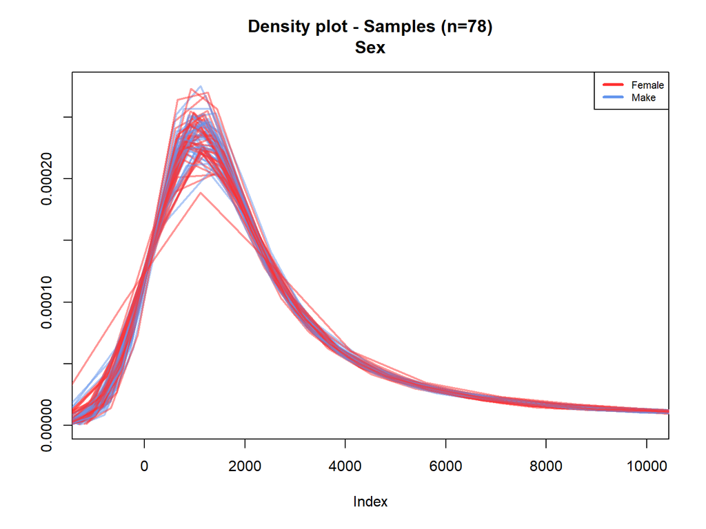

```r
plot(NA, xlim= c(-1000, 10000), ylim=range(sapply(dens, "[", "y")),
     main = "Density plot - Samples (n=78)\nSex", ylab="")
invisible(mapply(lines, dens, col=alpha(pheno2$Sex_col, 0.5), lwd = 2))
legend("topright", lty = 1, lwd = 3, pt.cex = 1.2, cex = 0.7,
       legend = c("Female", "Make"), col = c("firebrick1", "cornflowerblue"))
```

### Box plots

Re-check the boxplots

By SGA status

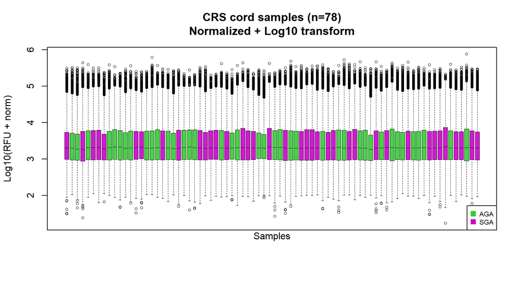

```r
boxplot(log10(dat1), main = "CRS cord samples (n=78)\nNormalized + Log10 transform",
        xlab = "Samples\n\n\n", ylab = "Log10(RFU + norm)", cex=0.6,
        bg.col = alpha("grey", 0.7), xaxt = 'n', lwd = 0.3,
        col = alpha(pheno2$SGA_col, 0.9))
legend("bottomright", pch=15, pt.cex = 1.2, cex = 0.7,
       legend = c("AGA", "SGA"), col = c("limegreen", "magenta3"))
```

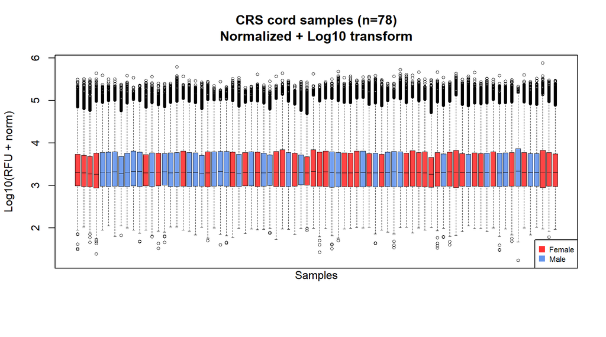

```r
boxplot(log10(dat1), main = "CRS cord samples (n=78)\nNormalized + Log10 transform",
        xlab = "Samples\n\n\n", ylab = "Log10(RFU + norm)", cex=0.6,
        bg.col = alpha("grey", 0.7), xaxt = 'n', lwd = 0.3,
        col = alpha(pheno2$Sex_col, 0.9))
legend("bottomright", pch=15, pt.cex = 1.2, cex = 0.7,
       legend = c("Female", "Male"), col = c("firebrick1", "cornflowerblue"))
```

### Cumulative Distribution Function

The CDF shows the proportion of aptamers that have RFU intensities below a range of values (on a Log10 scale). In general, the CDF exhibit a similar pattern for all samples. One of the flagged sample’s distibution sits a little lower, although the overall sigmoid shape remains the same.

For plotting purposes, randomize the sample order

```r
set.seed(42); datX = dat1[, sample(1:ncol(dat1), replace = FALSE)]
phenoX = pheno2[colnames(datX), ]
```

CDF by SGA

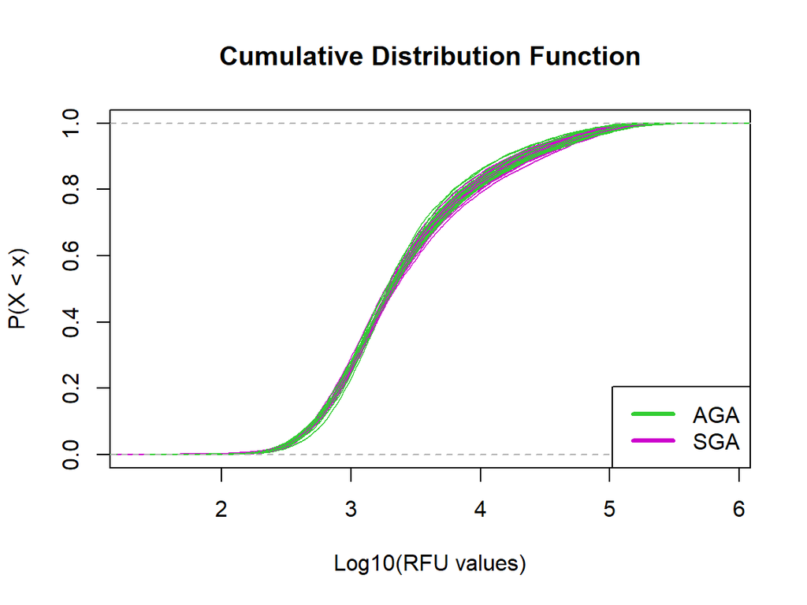

```r
CDF <- ecdf(as.numeric(log10(datX[, 1])))
plot(CDF, main = "Cumulative Distribution Function",
     xlab = "Log10(RFU values)", ylab = "P(X < x)", col = "white")
for(i in 1:ncol(datX)) {
  CDF2 <- ecdf(as.numeric(log10(datX[, i])))
  lines(CDF2, col = phenoX$SGA_col[[i]])
}
legend("bottomright", lty = 1, lwd = 3, pt.cex = 1.2, cex = 1,
       legend = c("AGA", "SGA"),
       col = c("limegreen", "magenta3"))
```

CDF by Sex

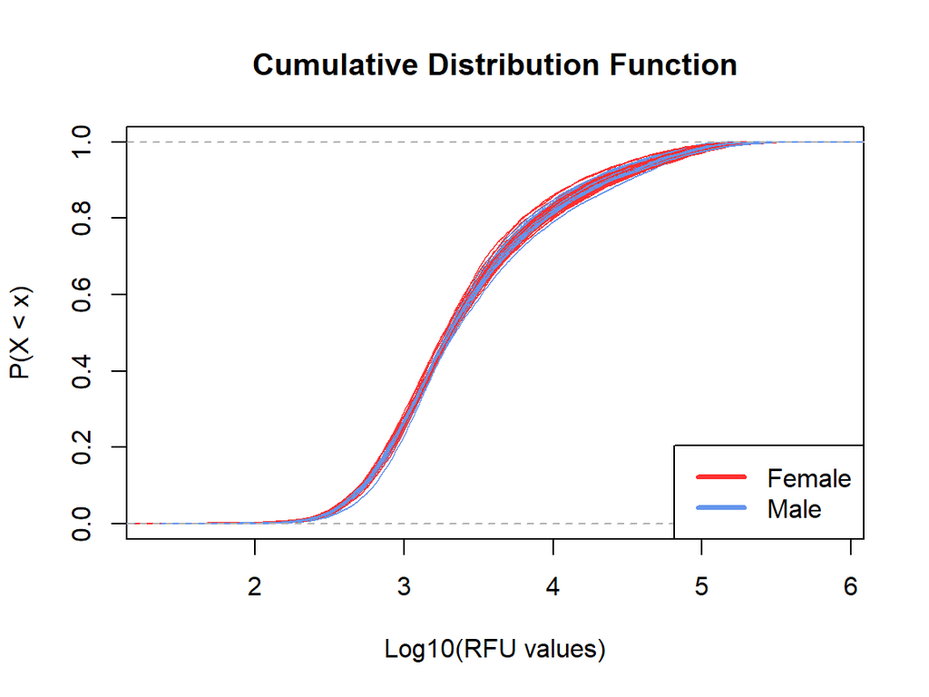

```r
CDF <- ecdf(as.numeric(log10(datX[, 1])))
plot(CDF, main = "Cumulative Distribution Function",
     xlab = "Log10(RFU values)", ylab = "P(X < x)", col = "white")
for(i in 1:ncol(datX)) {
  CDF2 <- ecdf(as.numeric(log10(datX[, i])))
  lines(CDF2, col = phenoX$Sex_col[[i]])
}
legend("bottomright", lty = 1, lwd = 3, pt.cex = 1.2, cex = 1,
       legend = c("Female", "Male"),
       col = c("firebrick1", "cornflowerblue"))
```

### Relative Log Expression

By SGA status

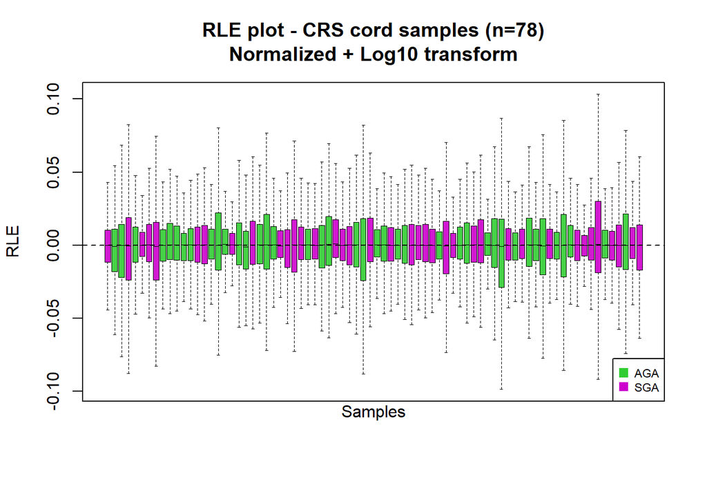

```r
plotRLE(as.matrix(log10(dat1)), main = "RLE plot - CRS cord samples (n=78)\nNormalized + Log10 transform",
        xlab = "Samples\n\n\n", ylab = "RLE", cex=0.6,
        bg.col = alpha("grey", 0.7), xaxt = 'n', lwd = 0.3,
        col = alpha(pheno2$SGA_col, 0.9), outline = FALSE)
legend("bottomright", pch=15, pt.cex = 1.2, cex = 0.7,
       legend = c("AGA", "SGA"), col = c("limegreen", "magenta3"))
```

By Sex status

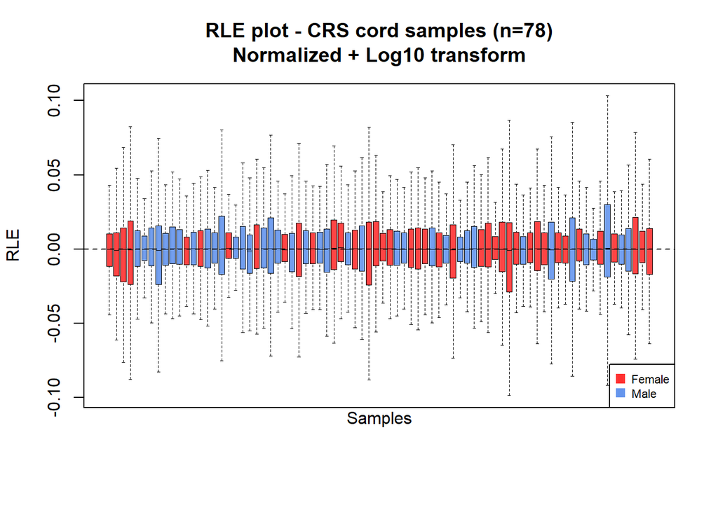

```r
plotRLE(as.matrix(log10(dat1)), main = "RLE plot - CRS cord samples (n=78)\nNormalized + Log10 transform",
        xlab = "Samples\n\n\n", ylab = "RLE", cex=0.6,
        bg.col = alpha("grey", 0.7), xaxt = 'n', lwd = 0.3,
        col = alpha(pheno2$Sex_col, 0.9), outline = FALSE)
legend("bottomright", pch=15, pt.cex = 1.2, cex = 0.7,
       legend = c("Female", "Male"), col = c("firebrick1", "cornflowerblue"))
```

### PCA analysis

Get top 2,000 most variable aptamers

```r
mostVar = apply(dat1, 1, var)
mostVar.idx = order(mostVar, decreasing = TRUE)[1:2000]
mostVar = mostVar[mostVar.idx]
datX = dat1[names(mostVar), ]
dim(datX)
```

```
## [1] 2000   78
```

Run PCA

```r
set.seed(42); yZ = PCA(t(dat1), ncp = 10, scale.unit = TRUE, graph = FALSE)
y1 = yZ$ind$coord
```

Plot the cumulative percentage of variance explained by the PCs.

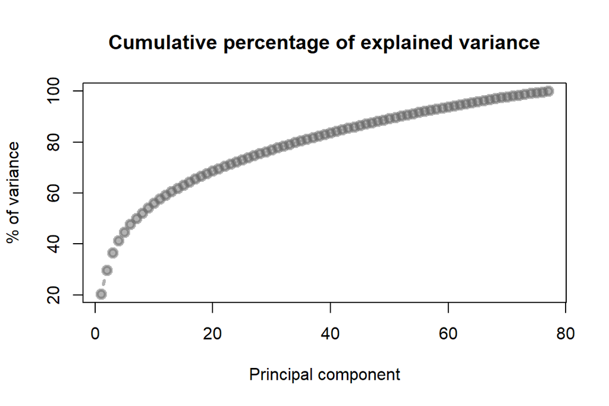

```r
plot(yZ$eig[, 3], pch=19, col = alpha("grey40", 0.5), cex = 1.2,
     type = "b", lwd=3, main = "Cumulative percentage of explained variance",
     xlab = "Principal component", ylab = "% of variance")
```

Plot percentage of variance explained by the first 20 components

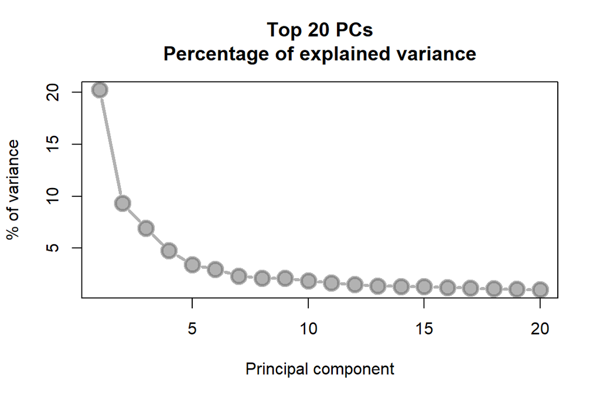

```r
plot(yZ$eig[1:20, 2], pch=19, col = alpha("grey40", 0.5), cex = 2,
     type = "b", lwd=3, names = 1:20, main = "Top 20 PCs\nPercentage of explained variance",
     xlab = "Principal component", ylab = "% of variance")
```

create dataframe of PCA outputs and phenodata

```r
w1 = data.frame(y1, pheno2)
```

Create axis label names

```r
lab1 = paste0("PC 1 (", round(yZ$eig[1, 2],2), "%)")
lab2 = paste0("PC 2 (", round(yZ$eig[2, 2],2), "%)")
lab3 = paste0("PC 3 (", round(yZ$eig[3, 2],2), "%)")
lab4 = paste0("PC 4 (", round(yZ$eig[4, 2],2), "%)")
```

PCA plots

PC1 and PC2 by sga

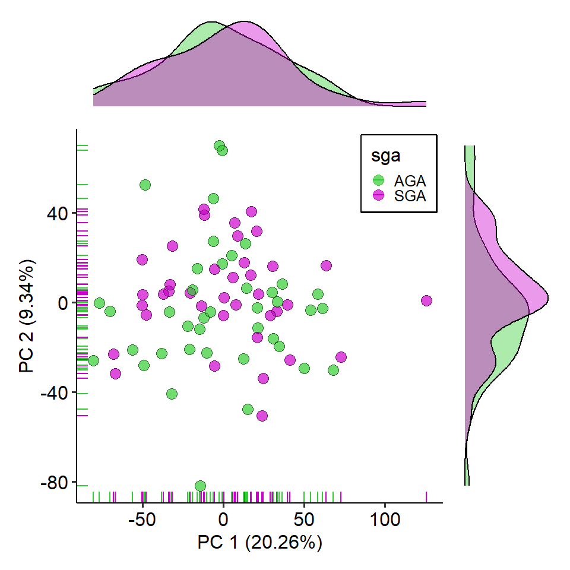

```r
plot1 = ggplot(w1, aes(x = Dim.1, y = Dim.2, color = sga)) +
  geom_point(aes(color = sga), size = 3, alpha = 0.7) +
  geom_point(shape = 1, color = "black", size = 3, alpha = 0.5) +
  geom_rug() + theme_pubr() + labs(x= lab1, y = lab2) +
  scale_color_manual(values=SGA_col) +
  theme(legend.position = c(.88, .88), legend.key.size = unit(0.25, 'cm'),
        legend.box.background = element_rect(color="black", linewidth=1))
dens1 <- ggplot(w1, aes(x = Dim.1, fill = sga)) + geom_density(alpha = 0.4) +
  theme_void() + theme(legend.position = "none") +
  scale_fill_manual(values=SGA_col)
dens2 <- ggplot(w1, aes(x = Dim.2, fill = sga)) + geom_density(alpha = 0.4) +
  theme_void() + theme(legend.position = "none") +
  scale_fill_manual(values=SGA_col) + coord_flip()
dens1 + plot_spacer() + plot1 + dens2 +
  plot_layout(ncol = 2, nrow = 2, widths = c(4, 1), heights = c(1, 4))
```

PC3 and PC4 by sga

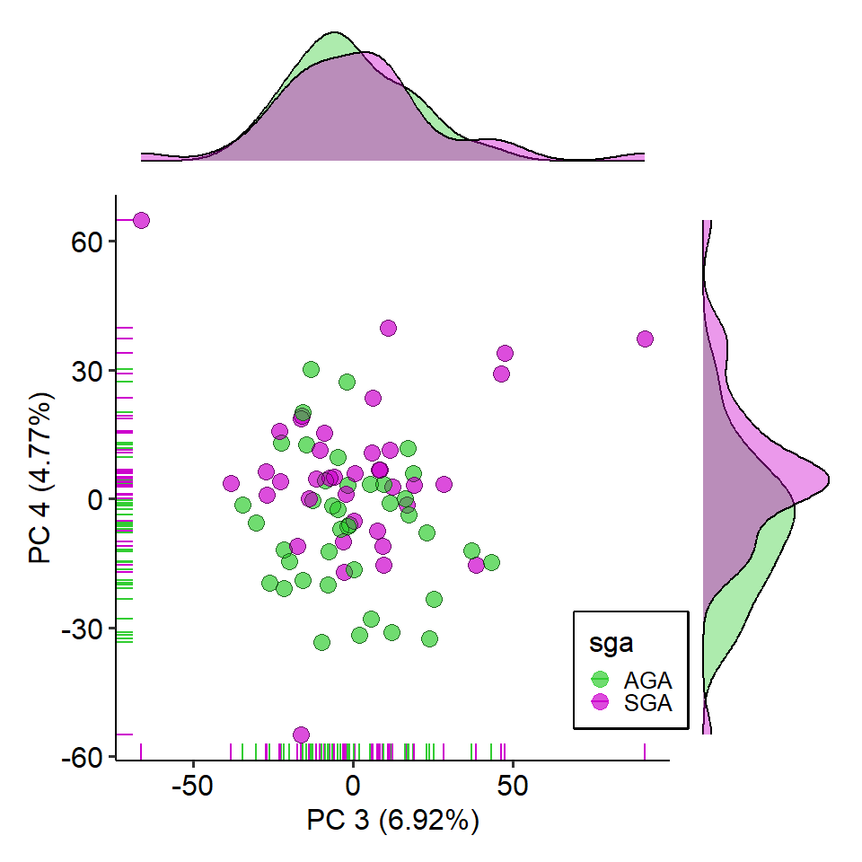

```r
plot1 = ggplot(w1, aes(x = Dim.3, y = Dim.4, color = sga)) +
  geom_point(aes(color = sga), size = 3, alpha = 0.7) +
  geom_point(shape = 1, color = "black", size = 3, alpha = 0.5) +
  geom_rug() + theme_pubr() + labs(x= lab3, y = lab4) +
  scale_color_manual(values=SGA_col)+
  theme(legend.position = c(.93, .16), legend.key.size = unit(0.25, 'cm'),
        legend.box.background = element_rect(color="black", linewidth=1))
dens1 <- ggplot(w1, aes(x = Dim.3, fill = sga)) + geom_density(alpha = 0.4) +
  theme_void() + theme(legend.position = "none") +
  scale_fill_manual(values=SGA_col)
dens2 <- ggplot(w1, aes(x = Dim.4, fill =sga)) + geom_density(alpha = 0.4) +
  theme_void() + theme(legend.position = "none") +
  scale_fill_manual(values=SGA_col) + coord_flip()
dens1 + plot_spacer() + plot1 + dens2 +
  plot_layout(ncol = 2, nrow = 2, widths = c(4, 1), heights = c(1, 4))
```

PC1 and PC2 by Sex

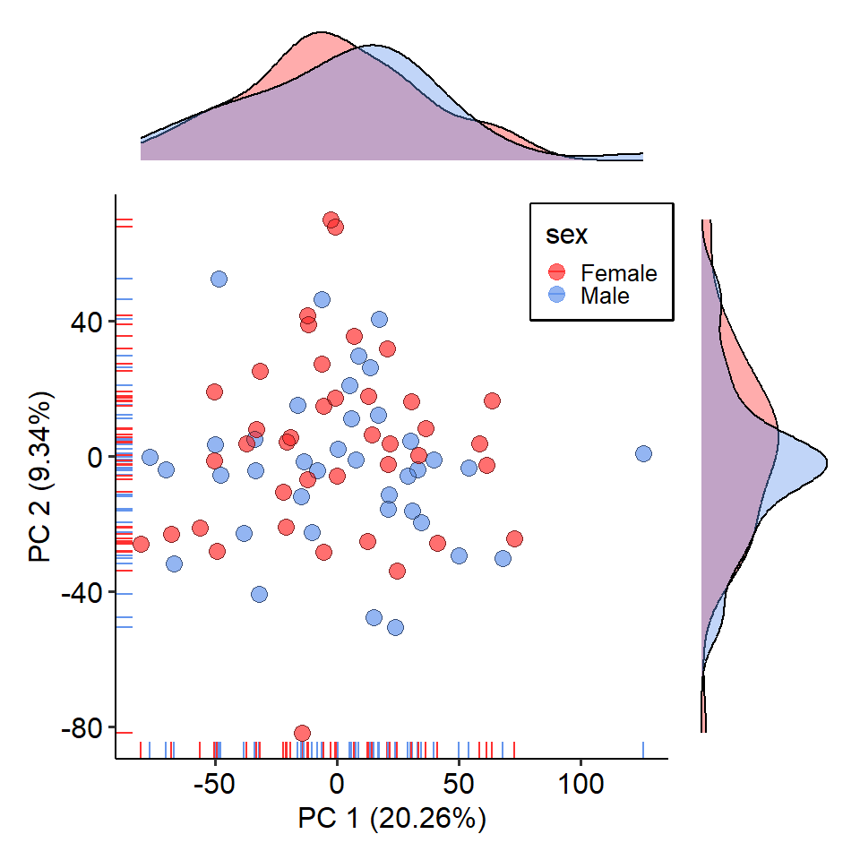

```r
plot1 = ggplot(w1, aes(x = Dim.1, y = Dim.2, color = sex)) +
  geom_point(aes(color = sex), size = 3, alpha = 0.7) +
  geom_point(shape = 1, color = "black", size = 3, alpha = 0.5) +
  geom_rug() + theme_pubr() + labs(x= lab1, y = lab2) +
  scale_color_manual(values=Sex_col) +
  theme(legend.position = c(.88, .88), legend.key.size = unit(0.25, 'cm'),
        legend.box.background = element_rect(color="black", linewidth=1))
dens1 <- ggplot(w1, aes(x = Dim.1, fill = sex)) + geom_density(alpha = 0.4) +
  theme_void() + theme(legend.position = "none") +
  scale_fill_manual(values=Sex_col)
dens2 <- ggplot(w1, aes(x = Dim.2, fill = sex)) + geom_density(alpha = 0.4) +
  theme_void() + theme(legend.position = "none") +
  scale_fill_manual(values=Sex_col) + coord_flip()
dens1 + plot_spacer() + plot1 + dens2 +
  plot_layout(ncol = 2, nrow = 2, widths = c(4, 1), heights = c(1, 4))
```

PC3 and PC4 by Sex

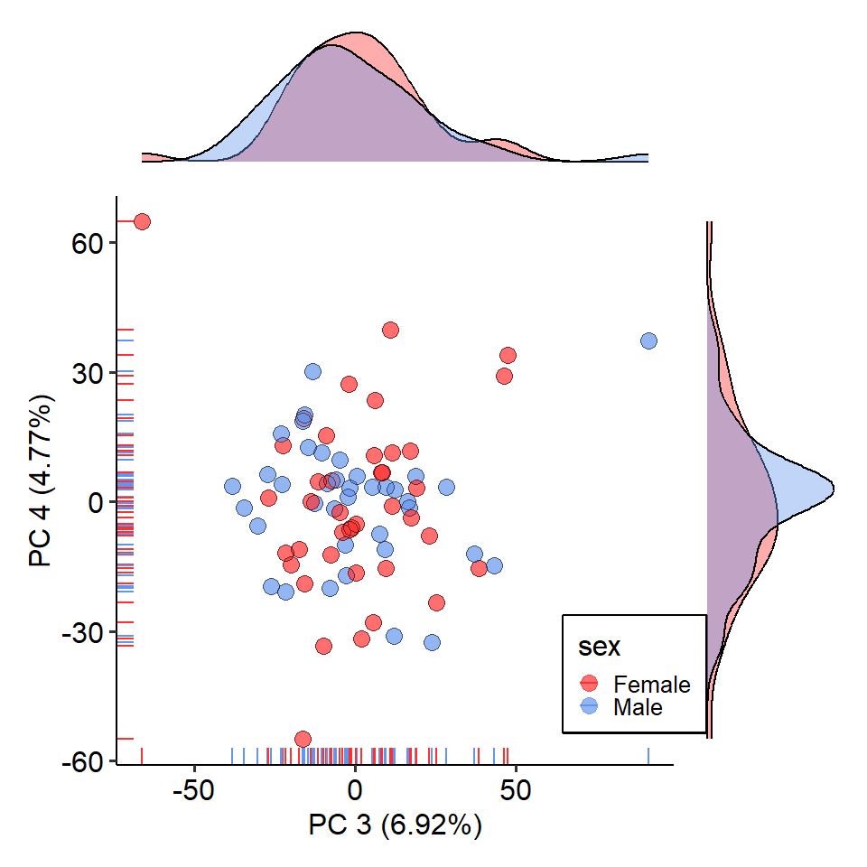

```r
plot1 = ggplot(w1, aes(x = Dim.3, y = Dim.4, color = sex)) +
  geom_point(aes(color = sex), size = 3, alpha = 0.7) +
  geom_point(shape = 1, color = "black", size = 3, alpha = 0.5) +
  geom_rug() + theme_pubr() + labs(x= lab3, y = lab4) +
  scale_color_manual(values=Sex_col)+
  theme(legend.position = c(.93, .16), legend.key.size = unit(0.25, 'cm'),
        legend.box.background = element_rect(color="black", linewidth=1))
dens1 <- ggplot(w1, aes(x = Dim.3, fill = sex)) + geom_density(alpha = 0.4) +
  theme_void() + theme(legend.position = "none") +
  scale_fill_manual(values=Sex_col)
dens2 <- ggplot(w1, aes(x = Dim.4, fill = sex)) + geom_density(alpha = 0.4) +
  theme_void() + theme(legend.position = "none") +
  scale_fill_manual(values=Sex_col) + coord_flip()
dens1 + plot_spacer() + plot1 + dens2 +
  plot_layout(ncol = 2, nrow = 2, widths = c(4, 1), heights = c(1, 4))
```

### Boxplots of top 6 PCA by variables

Organise data

```r
q1 = w1[, c(1, 48, 50, 101:102)]; q1$PC = "PC1"; colnames(q1)[[1]] = "Dim"
q2 = w1[, c(2, 48, 50, 101:102)]; q2$PC = "PC2"; colnames(q2)[[1]] = "Dim"
q3 = w1[, c(3, 48, 50, 101:102)]; q3$PC = "PC3"; colnames(q3)[[1]] = "Dim"
q4 = w1[, c(4, 48, 50, 101:102)]; q4$PC = "PC4"; colnames(q4)[[1]] = "Dim"
q5 = w1[, c(5, 48, 50, 101:102)]; q5$PC = "PC5"; colnames(q5)[[1]] = "Dim"
q6 = w1[, c(6, 48, 50, 101:102)]; q6$PC = "PC6"; colnames(q6)[[1]] = "Dim"
w2 = rbind(q1, q2, q3, q4, q5, q6)
w2[1:5, 1:5]
```

```
##                      Dim    sex sga        Sex_col   SGA_col
## 258633851958_1  -5.52447 Female SGA     firebrick1  magenta3
## 258633851967_1 -49.30182 Female AGA     firebrick1 limegreen
## 258633851990_1 -56.34606 Female AGA     firebrick1 limegreen
## 258633851991_1 -11.81423 Female SGA     firebrick1  magenta3
## 258633851960_1 -10.44152   Male AGA cornflowerblue limegreen
```

PCs by SGA

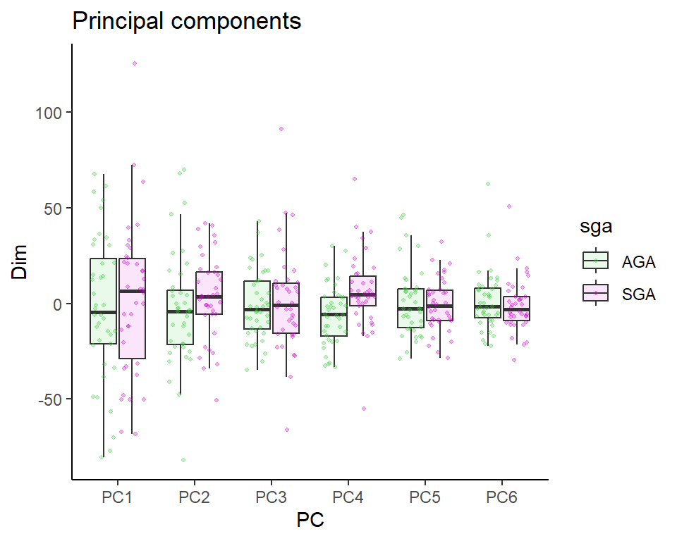

```r
ggplot(w2, aes(x=PC, y=Dim, fill=sga)) + ggtitle("Principal components")+
  geom_boxplot(outlier.shape = NA, alpha=0.1) + theme_classic() +
  geom_point(aes(color = sga),alpha=0.3, size = 0.75,
             position=position_jitterdodge(dodge.width = 0.75,
                                           jitter.width = 0.3))+
  scale_fill_manual(values=SGA_col)+ scale_color_manual(values=SGA_col)
```

PCs by Sex

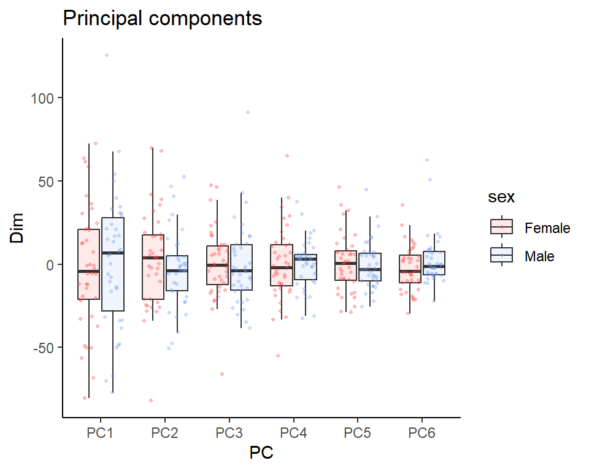

```r
ggplot(w2, aes(x=PC, y=Dim, fill=sex)) + ggtitle("Principal components")+
  geom_boxplot(outlier.shape = NA, alpha=0.1) + theme_classic() +
  geom_point(aes(color = sex),alpha=0.3, size = 0.75,
             position=position_jitterdodge(dodge.width = 0.75,
                                           jitter.width = 0.3))+
  scale_fill_manual(values=Sex_col)+ scale_color_manual(values=Sex_col)
```

Formally test PC vs Variables

Create dummy dataframe

```r
res.out = data.frame(Var = c(), PC1 = c(), PC2 = c(), PC3 = c(), PC4 = c(),
                     PC5 = c(), PC6 = c(), PC7 = c(), PC8 = c(), PC9 = c(),
                     PC10 = c())
```

Check data sets match

```r
identical(rownames(y1), rownames(w1))
```

```
## [1] TRUE
```

Test SGA status

```r
var1 = "sga"
i = 1
for(j in 1:10) {
  r1 = wilcox.test(y1[, j]~w1[,var1])
  res.out[i, "Var"] = var1
  res.out[i, paste("PC", j, sep="")] = r1$p.value
}
```

Test Sex status

```r
var1 = "sex"
i = 2
for(j in 1:10) {
  r1 = wilcox.test(y1[, j]~w1[,var1])
  res.out[i, "Var"] = var1
  res.out[i, paste("PC", j, sep="")] = r1$p.value
}
```

Organise dataframe

```r
rownames(res.out) = res.out$Var; res.out = res.out[, -1]
```

Caluculate -Log10 p values

```r
res.out2 = -log10(res.out)
```

Plot the results as a heatmap. Values above 1.3 (p = ~0.05) are colored increasing shades of red and identify statistically significant associations between PCs and variables of interest.

The graph show that SGA status was associated most prominently with PC4 (p < 0.001), and also with PC’s 8 & 9 (p < 0.05). Sex was not significanly associated with any of the tfirst 10 PCs.

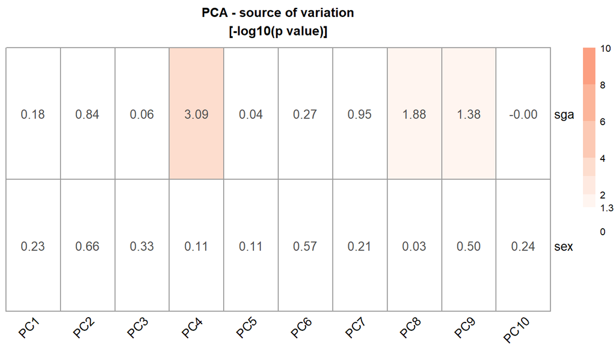

```r
pheatmap(res.out2, display_numbers = T,cluster_rows = FALSE, cluster_cols = FALSE,
         fontsize = 8, fontsize_number = 10,fontsize_row = 10, fontsize_col = 10,
         angle_col = 45, legend_breaks = c(0, 1.3, 2, 4, 6, 8, 10),
         legend = TRUE,breaks = c(0, 1.3, 2, 3, 4, 6, 8, 10),
         color = c("white", colorRampPalette(brewer.pal(n = 9,
                                                        name ="Reds"))(16)),
         main = "PCA - source of variation\n[-log10(p value)]")
```

### Batch correction

Technical plate/batch effects are largely mitigated by the standardization/normalization steps undertaken by SomaLogic.

However, if there are noably batch effect n the data (e.g., samples from different cohorts, sex, etc…), the *removeBatchEffect* function can be used to correct for these effect, and then the PCA analysis above can be re-run to determine the effectveness of the batch effect removal..

For example:

```r
# Not run
datX = removeBatchEffect(dat1, batch = pheno1$Cohort)
```

### Fisher’s test for variable enrichment

Test whether any of the experimental or technical variable show significant enrichment. Note: for 2x2 contingency tables, the odds ratio + 95% CI and p values are calculated; for contingency tables larger than 2x2, only the p value is given.

SGA and Sex *(not significant)*

```r
ft = as.data.frame.matrix(table(pheno2$sga, pheno2$sex))
ft
```

```
##     Female Male
## AGA     19   21
## SGA     21   17
```

```r
fisher.test(ft)
```

```
##
##  Fisher's Exact Test for Count Data
##
## data:  ft
## p-value = 0.5072
## alternative hypothesis: true odds ratio is not equal to 1
## 95 percent confidence interval:
##  0.2734366 1.9559023
## sample estimates:
## odds ratio
##  0.7353799
```

# Save samples

Check all datasets match

```r
identical(colnames(dat1), rownames(pheno2))
```

```
## [1] TRUE
```

```r
identical(rownames(dat1), rownames(analyte_pheno1))
```

```
## [1] TRUE
```

```r
out.dir = "Path/to/save/Directory"
```

Save data sets

```r
setwd(out.dir)
write.csv(dat1, "CRS_Cord_data_processed.csv")
write.csv(pheno2, "CRS_Cord_Sample_information.csv")
write.csv(analyte_pheno1, "CRS_Cord_Analyte_information.csv")
```

# Conclusions

There are 78 cord samples and 7,263 aptamers available for down stream analysis.

SomaLogic flagged 272 aptamers and these should also be monitor during downstream analysis. However, it is unlikely they need to be removed as variation in a number of aptamers is expected and often is a result of desirable biological variation.

The QC plots generated here showed no evidence of a sex difference in analyte measurements, although this should be monitered in downstream analysis.